# Late Round Prospect Guide — Evaluation 2022–2025

Nick Gurol

# Executive summary

We define the ground-truth tier from realized production (best PPR FFPG, Y1–Y3 post-draft):

| Production tier | Cutoff (PPR PPG) | Verbal anchor |
| --- | --- | --- |
| **Elite** | ≥ 16.5 | RB1 / WR1 cornerstone |
| **Starter** | 12 – 16.5 | RB2 / WR2 (weekly start) |
| **Flex** | 7 – 12 | FLEX-worthy |
| **Depth** | 3 – 7 | bench |
| **Dart Throw** | < 3 | irrelevant |

We compare JJ’s predicted tier (`canonical_tier` from his guide) to this production tier, alongside a baseline tier derived from `lm(best_ffppg ~ age + log(draft_pick))` binned with the same cutoffs.

Headline: JJ’s canonical_tier vs baseline lm(best_ffppg ~ age + log(draft_pick)) binned via same cutoffs.

| Position | N | JJ accuracy | Baseline accuracy | JJ κ | Baseline κ | JJ weighted F1 | Baseline weighted F1 | JJ off-by-one | Baseline off-by-one |
| --- | --- | --- | --- | --- | --- | --- | --- | --- | --- |
| WR | 127 | 0.370 | 0.370 | 0.487 | 0.508 | 0.347 | 0.362 | 0.811 | 0.890 |
| RB | 96 | 0.448 | 0.385 | 0.475 | 0.562 | 0.435 | 0.391 | 0.802 | 0.875 |

**Headline:** On both positions, the age + log(draft_pick) baseline matches or beats JJ’s canonical tier on quadratic kappa and off-by-one rate — confirming the regression result that draft capital captures most of his signal. The interesting story is in the per-tier breakdown below: where exactly he wins and loses.

# Methodology evolution 2022–2025

The guide evolved markedly across the four years studied.

- **2022–2024 (Z-Prospect Model):** Numeric tiers 1–15 (2022, 2023) or 1–12 (2024) drawn directly from the post-draft rookie rankings cheatsheet. No verbal tier semantics beyond ordinal position.
- **2025–2026 (ZAP Model):** Verbal tiers (Elite Producer → Dart Throw, plus a 2026-only Legendary Performer top tier). Each tier carries a production claim (e.g., “Weekly Starter — should provide stability in your starting lineup, think RB2/WR2”).

Features mentioned in methodology, by year

| feature | 2022 | 2023 | 2024 | 2025 |
| --- | --- | --- | --- | --- |
| Body Mass Index (BMI) | ✓ | ✓ | · | · |
| Speed Score | ✓ | · | ✓ | ✓ |
| age | ✓ | · | · | · |
| best-season reception share | ✓ | · | · | · |
| best-season total touchdown share | ✓ | · | · | · |
| best-season total yards per team play | ✓ | · | · | · |
| draft capital | ✓ | · | · | · |
| Breakout Age | ✓ | · | ✓ | · |
| Dominator Rating | ✓ | ✓ | · | · |
| early-declare status | ✓ | · | · | · |
| size | ✓ | · | · | · |
| best-season receptions per game | ✓ | · | · | · |
| best-season receiving yards per team pass attempt | ✓ | · | · | · |
| best-season touchdown share | ✓ | · | · | · |
| conference factor | ✓ | · | · | · |
| teammate factor | ✓ | · | · | · |
| Draft Capital Delta | ✓ | ✓ | ✓ | ✓ |
| Weight | · | ✓ | · | · |
| Speed Score (weight-adjusted 40-yard dash time) | · | ✓ | · | · |
| Age | · | ✓ | · | · |
| Best-season reception share (RB) | · | ✓ | · | · |
| Best-season total touchdown share (RB) | · | ✓ | · | · |
| Best-season total yards per team play (RB) | · | ✓ | · | · |
| Draft capital | · | ✓ | · | · |
| Breakout Age (WR) | · | ✓ | · | · |
| Early-declare status (WR) | · | ✓ | · | · |
| Size (WR — minor) | · | ✓ | · | · |
| Best-season receptions per game (WR) | · | ✓ | · | · |
| Best-season receiving yards per team pass attempt (WR) | · | ✓ | · | · |
| Best-season touchdown share (WR) | · | ✓ | · | · |
| Conference factor (WR) | · | ✓ | · | · |
| Teammate factor (WR) | · | ✓ | · | · |
| Statistical Comparables | · | ✓ | ✓ | ✓ |
| Height-adjusted Speed Score | · | ✓ | · | · |
| Yards per route run (PFF) | · | ✓ | · | · |
| PFF rushing grade | · | ✓ | · | · |
| Average depth of target (aDOT) | · | ✓ | · | · |
| Slot rate | · | ✓ | · | · |
| Yards after contact per attempt | · | ✓ | · | · |
| Target share | · | ✓ | · | · |
| Contested catch rate | · | ✓ | · | · |
| ZAP Model | · | · | ✓ | · |
| Z-Prospect Model | · | · | ✓ | · |
| Breakout Score | · | · | ✓ | ✓ |
| Fantasy Points Score | · | · | ✓ | · |
| Teammate Score | · | · | ✓ | ✓ |
| B2S (Best Two Seasons) | · | · | ✓ | ✓ |
| Early-Declare Status | · | · | ✓ | · |
| Reception Share | · | · | ✓ | · |
| Draft Capital | · | · | ✓ | · |
| Yards per Team Pass Attempt | · | · | ✓ | · |
| Total Yards per Team Play | · | · | ✓ | · |
| Yards per Route Run | · | · | ✓ | · |
| Journey Comparables | · | · | ✓ | ✓ |
| Year 2 Model | · | · | ✓ | ✓ |
| ZAP Model Cheatsheet | · | · | ✓ | · |
| Rookie Rankings Cheatsheet | · | · | ✓ | · |
| ZAP Score | · | · | · | ✓ |
| ZAP Score Category | · | · | · | ✓ |
| Early-declare status | · | · | · | ✓ |
| Reception share | · | · | · | ✓ |
| Yards per route run | · | · | · | ✓ |
| Strength of schedule (Sports Reference) | · | · | · | ✓ |
| Receiving yards per team pass attempt | · | · | · | ✓ |
| Rushing production | · | · | · | ✓ |
| Size (height/weight) | · | · | · | ✓ |
| Draft-day age | · | · | · | ✓ |
| Mock draft big board data | · | · | · | ✓ |

# Tier definitions — his and ours

## How JJ defines each tier

The verbal tier scheme (2025–2026) is the only year-range where JJ publishes explicit definitions. **Each tier is a band of the ZAP Score** (his model output, 0–100 scale; higher = better prospect):

| Canonical bucket | JJ’s verbal tier (2025–2026) | Stated ZAP score band | JJ’s production claim |
| --- | --- | --- | --- |
| Elite | Legendary Performer *(2026 only)* | 90–100 | “Generational talent. Hit at outstanding rates historically. Cornerstone dynasty asset.” |
| Elite | Elite Producer | 75–90 | “Best of the best. Legitimate shot at a cornerstone piece.” |
| Starter | Weekly Starter | 60–75 | “Stability in your starting lineup. Think RB2/WR2.” |
| Flex | Flex Play | 40–60 | “Rarely become league-winners. Can provide usable production.” |
| Depth | Benchwarmer | 30–40 | “Perfect for bench insurance.” |
| Depth | Waiver Wire Add | 20–30 | “Probably doesn’t need to be rostered, but can occasionally be usable.” |
| Dart Throw | Dart Throw | 0–20 | “Very little chance for success.” |

For **2022–2024**, JJ uses purely **numeric tiers** from his Post-Draft Rookie Rankings Cheatsheet (Tier 1 → Tier 15 in 2022/2023; Tier 1 → Tier 12 in 2024 + an “Unranked” bucket for players he profiled but didn’t rank). There is no verbal label or stated FFPG/ZAP cutoff per tier in those years — the “definition” is just rank order in the cheatsheet.

## How WE map his tiers to our canonical 5-tier scheme

To compare across years, we collapse every year’s tier nomenclature to **{Elite, Starter, Flex, Depth, Dart Throw}** (canonical 5-tier scheme). The full mapping lives in `extraction/output/tier_map.json`; here’s the summary by year:

| Canonical | 2022 (numeric 1–15) | 2023 (Tier 1–15) | 2024 (Tier 1–12 + Unranked) | 2025 / 2026 (verbal) |
| --- | --- | --- | --- | --- |
| **Elite** | 1 | Tier 1 | Tier 1 | Legendary Performer / Elite Producer |
| **Starter** | 2–3 | Tier 2–3 | Tier 2–3 | Weekly Starter |
| **Flex** | 4–6 | Tier 4–6 | Tier 4–5 | Flex Play |
| **Depth** | 7–9 | Tier 7–9 | Tier 6–8 | Benchwarmer / Waiver Wire Add |
| **Dart Throw** | 10–15 + Z-Prospect Ranked | Tier 10–15 | Tier 9–12 + Unranked | Dart Throw |

Numeric tiers (2022–2024) were collapsed by proportional bucketing: ~top 7% → Elite, next ~15% → Starter, etc. The harmonizer’s full rationale is in `tier_map.json` under the `rationale` key.

## Empirical ZAP score distribution by canonical tier (2024–2026)

What ZAP score does each canonical tier actually carry, year by year? (Players without ZAP scores — 2022/2023 cheatsheet-only — are excluded.)

Mean ZAP score by canonical tier and year (WR+RB only; 2022/2023 NA)

| guide_year | Elite | Starter | Flex | Depth | Dart Throw |
| --- | --- | --- | --- | --- | --- |
| 2024 | 99.3 | 97.8 | 94.6 | 81.7 | 45.2 |
| 2025 | 97.0 | 88.7 | 75.6 | 50.5 | 13.3 |
| 2026 | 87.0 | 65.4 | 47.3 | 27.5 | 8.8 |

The 2024 mapping looks compressed near the top because 2024 used many fine-grained numeric tiers; our canonical 5-tier collapse puts everyone Tier 1–5 into Elite/Starter/Flex, all with ZAP scores above 80. 2025/2026 verbal tiers spread across the full ZAP range more evenly.

# Coverage 2022–2026

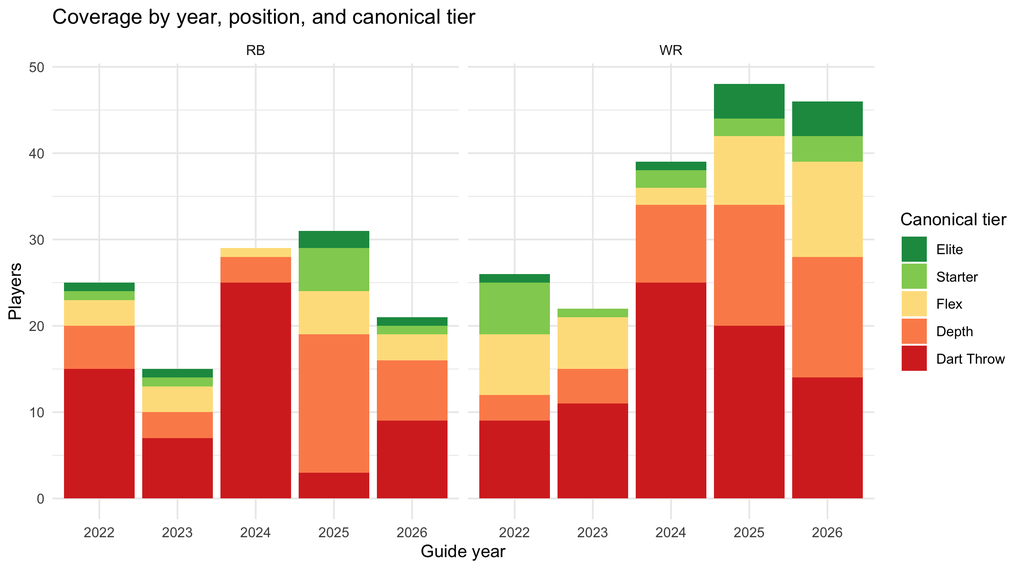

WR + RB players per guide year

| guide_year | RB | WR |
| --- | --- | --- |
| 2022 | 25 | 26 |
| 2023 | 15 | 22 |
| 2024 | 29 | 39 |
| 2025 | 31 | 48 |
| 2026 | 21 | 46 |

**Note on 2026:** the 2026 class was extracted and harmonized but is excluded from all eval metrics. Player birthdates aren’t yet in nflreadr for these rookies, and even if matched, they have no NFL season data yet.

# Production tier distribution

How many of each FFPG-defined tier did 2022–2025 rookies actually produce?

Production tier counts (eval set, 2022-2025)

[output not shown]

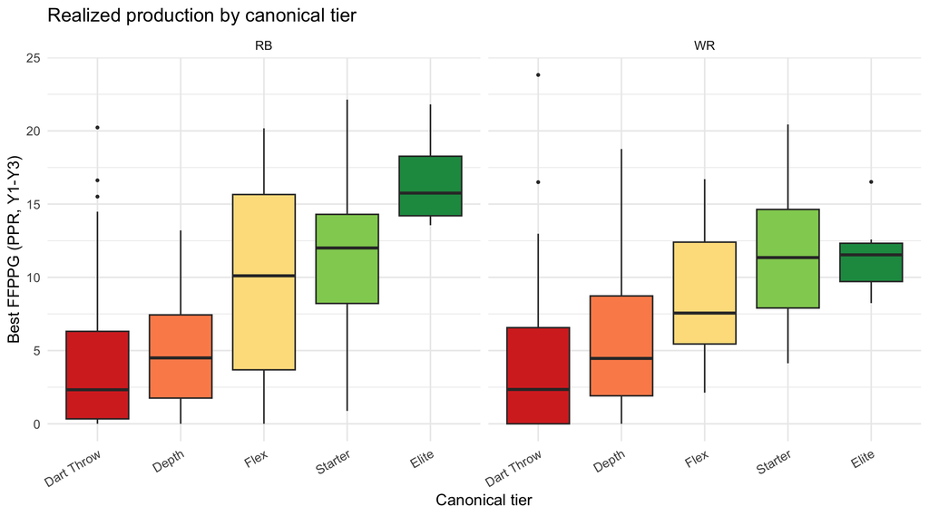

The boxplot still uses JJ’s `canonical_tier` on the x-axis — it shows that his Elite/Starter calls do produce higher PPG on average, just with massive variance.

# How JJ’s tier compares to the production tier

Below we compare JJ’s predicted `canonical_tier` (from his guide) directly to the FFPG-defined `production_tier` (truth). For reference we also compare a baseline that predicts FFPG from `age + log(draft_pick)` and bins the prediction with the same cutoffs.

## Confusion matrices

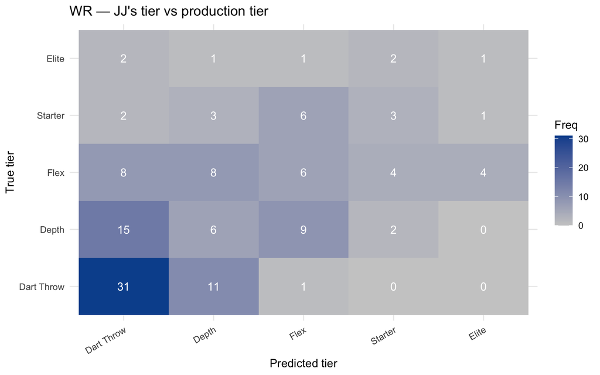

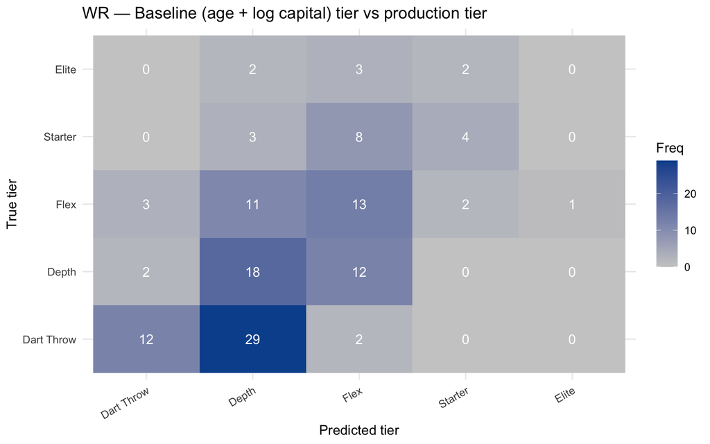

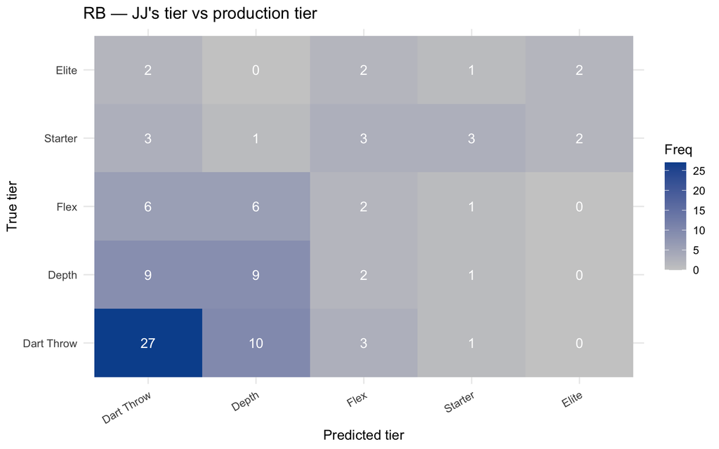

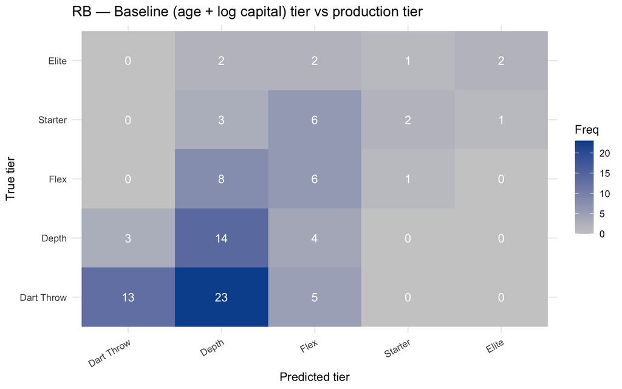

Each row is the true tier (production-derived); each column is the predicted tier. Diagonal = correct, off-diagonal = miss.

## Per-tier precision, recall, F1

### WR

**JJ’s predictions:**

| tier | support | precision | recall | f1 |
| --- | --- | --- | --- | --- |
| Dart Throw | 43 | 0.534 | 0.721 | 0.614 |
| Depth | 32 | 0.207 | 0.188 | 0.197 |
| Flex | 30 | 0.261 | 0.200 | 0.226 |
| Starter | 15 | 0.273 | 0.200 | 0.231 |
| Elite | 7 | 0.167 | 0.143 | 0.154 |

**Baseline (age + log capital) predictions:**

| tier | support | precision | recall | f1 |
| --- | --- | --- | --- | --- |
| Dart Throw | 43 | 0.706 | 0.279 | 0.400 |
| Depth | 32 | 0.286 | 0.562 | 0.379 |
| Flex | 30 | 0.342 | 0.433 | 0.382 |
| Starter | 15 | 0.500 | 0.267 | 0.348 |
| Elite | 7 | 0.000 | 0.000 | NA |

### RB

**JJ’s predictions:**

| tier | support | precision | recall | f1 |
| --- | --- | --- | --- | --- |
| Dart Throw | 41 | 0.574 | 0.659 | 0.614 |
| Depth | 21 | 0.346 | 0.429 | 0.383 |
| Flex | 15 | 0.167 | 0.133 | 0.148 |
| Starter | 12 | 0.429 | 0.250 | 0.316 |
| Elite | 7 | 0.500 | 0.286 | 0.364 |

**Baseline (age + log capital) predictions:**

| tier | support | precision | recall | f1 |
| --- | --- | --- | --- | --- |
| Dart Throw | 41 | 0.812 | 0.317 | 0.456 |
| Depth | 21 | 0.280 | 0.667 | 0.394 |
| Flex | 15 | 0.261 | 0.400 | 0.316 |
| Starter | 12 | 0.500 | 0.167 | 0.250 |
| Elite | 7 | 0.667 | 0.286 | 0.400 |

## Tier-call calibration: do his Elite calls actually become Elite?

The diagonal cells of the confusion matrix above answer this directly. Pulling out the high-stakes tiers (Starter + Elite, where his model is essentially “this guy is fantasy-relevant”):

Calibration: for each predicted tier, what fraction of calls were exactly correct vs. at-or-above the predicted tier.

| position | predicted_tier | n_called | frac_at_or_above | frac_exact | predictor |
| --- | --- | --- | --- | --- | --- |
| RB | Elite | 3 | 67% | 67% | Baseline |
| RB | Starter | 4 | 75% | 50% | Baseline |
| RB | Flex | 23 | 61% | 26% | Baseline |
| RB | Depth | 50 | 54% | 28% | Baseline |
| RB | Dart Throw | 16 | 100% | 81% | Baseline |
| RB | Elite | 4 | 50% | 50% | JJ |
| RB | Starter | 7 | 57% | 43% | JJ |
| RB | Flex | 12 | 58% | 17% | JJ |
| RB | Depth | 26 | 62% | 35% | JJ |
| RB | Dart Throw | 47 | 100% | 57% | JJ |
| WR | Elite | 1 | 0% | 0% | Baseline |
| WR | Starter | 8 | 75% | 50% | Baseline |
| WR | Flex | 38 | 63% | 34% | Baseline |
| WR | Depth | 63 | 54% | 29% | Baseline |
| WR | Dart Throw | 17 | 100% | 71% | Baseline |
| WR | Elite | 6 | 17% | 17% | JJ |
| WR | Starter | 11 | 45% | 27% | JJ |
| WR | Flex | 23 | 57% | 26% | JJ |
| WR | Depth | 29 | 62% | 21% | JJ |
| WR | Dart Throw | 58 | 100% | 53% | JJ |

# Regression — supplementary

The original regression-style read on the question “does his tier add over draft capital + age?” Same conclusion as the classification: no statistically significant signal.

| Position | N | Baseline adj R² | + canonical_tier adj R² | ΔR² | F-test p |
| --- | --- | --- | --- | --- | --- |
| WR | 127 | 0.40 | 0.39 | -0.00 | 0.514 |
| RB | 96 | 0.39 | 0.38 | -0.02 | 0.859 |

# Slices — where (if anywhere) does he add value?

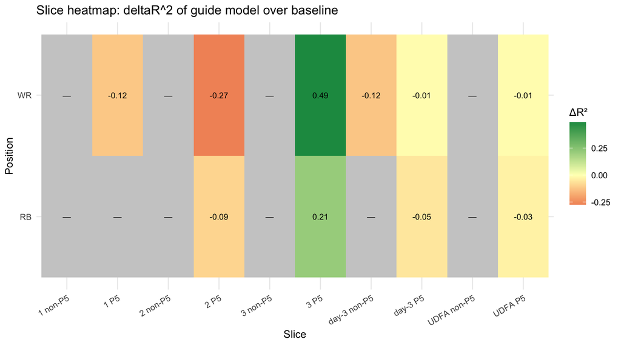

Production by position × draft round × P5. starter_plus_rate = fraction that reached production_tier Starter or Elite (best FFPG ≥ 12).

| position | draft_round | p5_flag | n | mean_ffppg | starter_plus_rate |
| --- | --- | --- | --- | --- | --- |
| RB | 1 | FALSE | 1 | 14.42 | 100% |
| RB | 1 | TRUE | 3 | 19.17 | 100% |
| RB | 2 | TRUE | 8 | 12.35 | 62% |
| RB | 3 | FALSE | 1 | 9.47 | 0% |
| RB | 3 | TRUE | 9 | 7.97 | 22% |
| RB | UDFA | FALSE | 5 | 2.01 | 0% |
| RB | UDFA | TRUE | 15 | 0.78 | 0% |
| RB | day-3 | FALSE | 6 | 3.01 | 0% |
| RB | day-3 | TRUE | 51 | 5.97 | 16% |
| WR | 1 | TRUE | 21 | 12.73 | 57% |
| WR | 2 | FALSE | 2 | 7.93 | 0% |
| WR | 2 | TRUE | 17 | 8.49 | 24% |
| WR | 3 | FALSE | 3 | 4.89 | 0% |
| WR | 3 | TRUE | 13 | 7.11 | 23% |
| WR | UDFA | FALSE | 2 | 4.95 | 0% |
| WR | UDFA | TRUE | 22 | 1.13 | 0% |
| WR | day-3 | FALSE | 9 | 5.94 | 11% |
| WR | day-3 | TRUE | 43 | 4.32 | 5% |

# Sleeper detection — when JJ disagrees with draft capital

**Operational definition:** a JJ sleeper is a player where JJ’s ZAP score (0–100) is higher than the draft-capital-and-age baseline score (also 0–100, percentile-ranked within position). The baseline is `lm(best_ffppg ~ age + log(draft_pick))` predictions, ranked.

**JJ score** is on a 0-100 scale: ZAP score directly for 2024-2026 (where JJ publishes it per-player), and a tier midpoint for 2022-2023 (where the cheatsheet only gives ordinal tier; we use JJ’s own stated 2026 ZAP-band midpoints — Dart Throw=10, Depth=30, Flex=50, Starter=67.5, Elite=87.5). **Baseline score** is the percentile rank within position of `lm(best_ffppg ~ age + log(draft_pick))` predictions.

Coverage: **223 total players** in the score table — **137** with native ZAP (2024-25), **86** with tier-midpoint fallback (2022-23).

## How often does JJ disagree with draft capital?

Counts of (JJ score) vs (baseline percentile score) disagreement, 2022-2025 full eval set

[output not shown]

## The scatter — score-vs-score, colored by actual production tier

Each point is a 2022–2025 rookie. The diagonal is “JJ agrees with draft capital.” Points above = JJ-bumps; below = JJ-fades. Color = actual production tier. Triangles = day-3/UDFA, circles = early-round. Top 5 biggest disagreements each way (per position) are name-labeled.

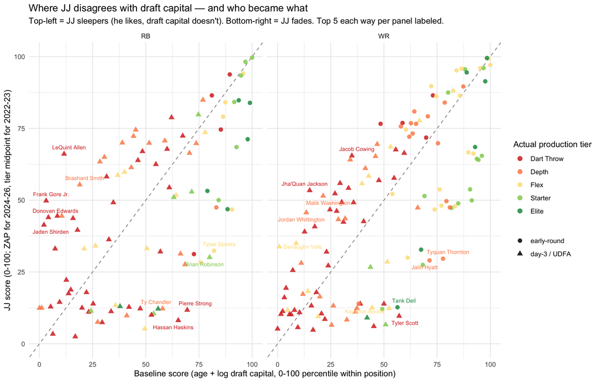

## Outcomes by JJ-bump magnitude

If JJ has any independent signal, players he scores meaningfully higher than the baseline should hit Starter+ at higher rates than players where he agrees with the baseline (or fades).

| position | bump_bucket | n | mean_ffppg | starter_plus_rate | elite_rate | bust_rate |
| --- | --- | --- | --- | --- | --- | --- |
| RB | Big JJ bump (+30 or more) | 10 | 2.55 | 0% | 0% | 50% |
| RB | Moderate JJ bump (+10 to +30) | 17 | 3.82 | 0% | 0% | 47% |
| RB | Neutral (within +-10) | 29 | 5.69 | 21% | 3% | 48% |
| RB | Moderate JJ fade (-10 to -30) | 19 | 8.81 | 37% | 16% | 42% |
| RB | Big JJ fade (-30 or worse) | 21 | 8.25 | 29% | 14% | 29% |
| WR | Big JJ bump (+30 or more) | 5 | 3.77 | 0% | 0% | 40% |
| WR | Moderate JJ bump (+10 to +30) | 38 | 3.98 | 0% | 0% | 45% |
| WR | Neutral (within +-10) | 39 | 5.62 | 13% | 5% | 44% |
| WR | Moderate JJ fade (-10 to -30) | 25 | 8.51 | 28% | 8% | 16% |
| WR | Big JJ fade (-30 or worse) | 20 | 10.33 | 50% | 15% | 15% |

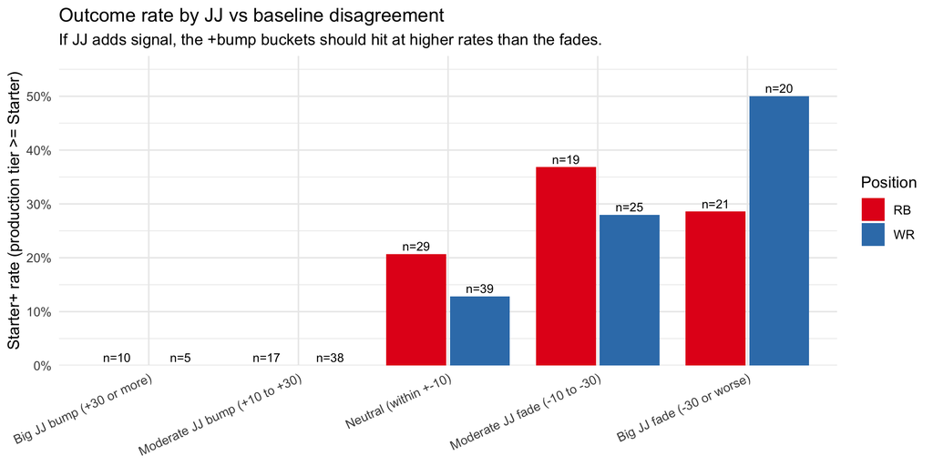

## Late-round only (day-3 + UDFA)

Outcomes by JJ-vs-baseline gap bucket — late-round only (day-3 + UDFA)

| position | bump_bucket | n | mean_ffppg | starter_plus_rate | elite_rate | bust_rate |
| --- | --- | --- | --- | --- | --- | --- |
| RB | Big JJ bump (+30 or more) | 10 | 2.55 | 0% | 0% | 50% |
| RB | Moderate JJ bump (+10 to +30) | 17 | 3.82 | 0% | 0% | 47% |
| RB | Neutral (within +-10) | 19 | 3.47 | 5% | 0% | 63% |
| RB | Moderate JJ fade (-10 to -30) | 15 | 7.07 | 27% | 7% | 47% |
| RB | Big JJ fade (-30 or worse) | 13 | 6.28 | 23% | 8% | 38% |
| WR | Big JJ bump (+30 or more) | 5 | 3.77 | 0% | 0% | 40% |
| WR | Moderate JJ bump (+10 to +30) | 26 | 3.41 | 0% | 0% | 54% |
| WR | Neutral (within +-10) | 21 | 2.23 | 0% | 0% | 76% |
| WR | Moderate JJ fade (-10 to -30) | 12 | 5.23 | 8% | 0% | 33% |
| WR | Big JJ fade (-30 or worse) | 7 | 8.12 | 29% | 14% | 43% |

## Named JJ-bump cases (biggest disagreements where JJ was more bullish)

Top 15 JJ-bump players — biggest positive disagreement vs baseline. production_tier and best_ffppg show what actually happened.

| name | position | guide_year | draft_round | baseline_score | jj_score | bump | production_tier | best_ffppg |
| --- | --- | --- | --- | --- | --- | --- | --- | --- |
| LeQuint Allen | RB | 2025 | day-3 | 11.6 | 66.1 | 54.5 | Dart Throw | 1.6 |
| Frank Gore Jr. | RB | 2024 | UDFA | 3.2 | 49.8 | 46.6 | Dart Throw | 0.8 |
| Donovan Edwards | RB | 2025 | UDFA | 4.2 | 44.0 | 39.8 | Dart Throw | 0.0 |
| Jaden Shirden | RB | 2024 | UDFA | 2.1 | 41.4 | 39.3 | Dart Throw | 0.0 |
| Jha’Quan Jackson | WR | 2024 | day-3 | 15.1 | 53.4 | 38.3 | Dart Throw | 0.1 |
| Brashard Smith | RB | 2025 | day-3 | 18.9 | 55.4 | 36.5 | Depth | 3.7 |
| Montrell Johnson | RB | 2025 | UDFA | 8.4 | 44.5 | 36.1 | Dart Throw | 0.0 |
| Ollie Gordon | RB | 2025 | day-3 | 28.4 | 63.4 | 35.0 | Depth | 3.2 |
| Devin Neal | RB | 2025 | day-3 | 30.5 | 65.0 | 34.5 | Depth | 6.7 |
| Raheim Sanders | RB | 2025 | UDFA | 10.5 | 44.5 | 34.0 | Depth | 5.1 |
| Devaughn Vele | WR | 2024 | day-3 | 0.8 | 33.8 | 33.0 | Flex | 7.6 |
| Jordan Whittington | WR | 2024 | day-3 | 13.5 | 45.7 | 32.2 | Depth | 3.4 |
| Isaiah Davis | RB | 2024 | day-3 | 38.9 | 70.0 | 31.1 | Depth | 4.5 |
| Jacob Cowing | WR | 2024 | day-3 | 34.9 | 65.5 | 30.6 | Dart Throw | 0.8 |
| Malik Washington | WR | 2024 | day-3 | 21.4 | 51.5 | 30.1 | Depth | 6.9 |

## Named JJ-fade cases (biggest disagreements where JJ was more bearish)

Top 15 JJ-fade players — biggest negative disagreement vs baseline.

| name | position | guide_year | draft_round | baseline_score | jj_score | bump | production_tier | best_ffppg |
| --- | --- | --- | --- | --- | --- | --- | --- | --- |
| Pierre Strong | RB | 2022 | day-3 | 69.5 | 10.0 | -59.5 | Dart Throw | 2.7 |
| Hassan Haskins | RB | 2022 | day-3 | 65.3 | 10.0 | -55.3 | Dart Throw | 2.6 |
| Tyjae Spears | RB | 2023 | 3 | 82.1 | 30.0 | -52.1 | Flex | 9.5 |
| Brian Robinson | RB | 2022 | day-3 | 80.0 | 30.0 | -50.0 | Starter | 13.2 |
| Ty Chandler | RB | 2022 | day-3 | 57.9 | 10.0 | -47.9 | Depth | 6.3 |
| Tyquan Thornton | WR | 2022 | 2 | 77.8 | 30.0 | -47.8 | Depth | 5.5 |
| Tyler Scott | WR | 2023 | day-3 | 57.1 | 10.0 | -47.1 | Dart Throw | 2.8 |
| Tank Dell | WR | 2023 | 3 | 56.3 | 10.0 | -46.3 | Elite | 16.5 |
| Tank Bigsby | RB | 2023 | 3 | 75.8 | 30.0 | -45.8 | Flex | 8.1 |
| Chase Brown | RB | 2023 | day-3 | 55.8 | 10.0 | -45.8 | Elite | 16.6 |
| Jawhar Jordan | RB | 2024 | day-3 | 49.5 | 5.2 | -44.3 | Flex | 7.4 |
| Jerome Ford | RB | 2022 | day-3 | 53.7 | 10.0 | -43.7 | Starter | 12.1 |
| Ty Davis-Price | RB | 2022 | 3 | 72.6 | 30.0 | -42.6 | Dart Throw | 2.1 |
| Eric Gray | RB | 2023 | day-3 | 52.6 | 10.0 | -42.6 | Dart Throw | 1.4 |
| Kayshon Boutte | WR | 2023 | day-3 | 52.4 | 10.0 | -42.4 | Flex | 8.7 |

# Ranking quality — for dynasty drafting

If you’re using one of these rankings to draft (1.01, 1.02, 1.03…), how well does each one order players against actual production? Three views.

## Spearman rank correlation with actual best_ffppg

Spearman rank correlation of each score with actual best_ffppg.

| Position | N | Spearman: JJ vs actual | Spearman: Baseline vs actual |
| --- | --- | --- | --- |
| WR | 127 | 0.337 | 0.669 |
| RB | 96 | 0.269 | 0.616 |

## Top-K precision — of the top K by each ranking, what fraction were truly top K?

Of the top K players each ranker selected, fraction that were actually top K by best_ffppg.

| position | k | jj_precision | baseline_precision |
| --- | --- | --- | --- |
| WR | 5 | 20% | 20% |
| WR | 10 | 20% | 50% |
| WR | 20 | 30% | 60% |
| WR | 30 | 33% | 63% |
| RB | 5 | 0% | 40% |
| RB | 10 | 20% | 40% |
| RB | 20 | 35% | 60% |
| RB | 30 | 40% | 63% |

## Cumulative production curve

If you drafted strictly in each ranker’s order, this is the total `best_ffppg` you would have accumulated as you went down the list. Steeper = better ranker (picks the productive players first). The dashed line is the oracle upper bound (ranking by actual production).

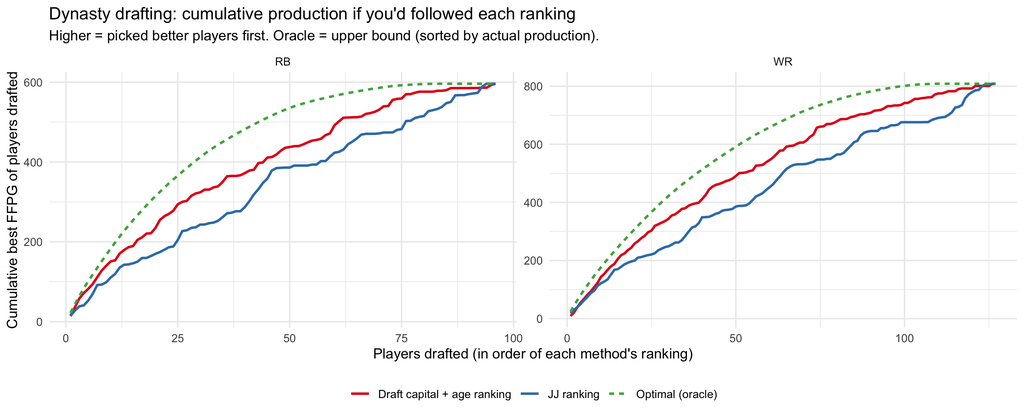

## Pearson correlation with continuous best_ffppg

Pearson correlation of each score with continuous best_ffppg. pearson_zap_only_2024_25 restricts to ZAP-available years for a like-for-like ZAP-vs-baseline comparison.

| position | n_total | n_with_zap | pearson_jj | pearson_baseline | pearson_zap_only_2024_25 |
| --- | --- | --- | --- | --- | --- |
| WR | 127 | 79 | 0.301 | 0.630 | 0.616 |
| RB | 96 | 58 | 0.264 | 0.586 | 0.474 |

# Year-by-year scorecard

## 2022 class

| name | position | canonical_tier | draft_round | best_ffppg |
| --- | --- | --- | --- | --- |
| Drake London | WR | Elite | 1 | 16.52 |
| Breece Hall | RB | Elite | 2 | 17.09 |
| Garrett Wilson | WR | Starter | 1 | 14.82 |
| Chris Olave | WR | Starter | 1 | 14.46 |
| Jameson Williams | WR | Starter | 1 | 14.07 |
| Jahan Dotson | WR | Starter | 1 | 10.88 |
| Treylon Burks | WR | Starter | 1 | 8.01 |
| Kenneth Walker | RB | Starter | 2 | 16.47 |
| Skyy Moore | WR | Starter | 2 | 4.13 |
| Christian Watson | WR | Flex | 2 | 11.72 |
| Wan’Dale Robinson | WR | Flex | 2 | 10.75 |
| John Metchie | WR | Flex | 2 | 5.48 |
| George Pickens | WR | Flex | 2 | 12.27 |
| Alec Pierce | WR | Flex | 2 | 10.09 |
| James Cook | RB | Flex | 2 | 17.07 |
| Jalen Tolbert | WR | Flex | 3 | 8.94 |
| Rachaad White | RB | Flex | 3 | 15.55 |
| David Bell | WR | Flex | day-3 | 6.21 |
| Dameon Pierce | RB | Flex | day-3 | 12.80 |
| Tyquan Thornton | WR | Depth | 2 | 5.52 |
| Ty Davis-Price | RB | Depth | 3 | 2.10 |
| Brian Robinson | RB | Depth | day-3 | 13.21 |
| Zamir White | RB | Depth | day-3 | 5.68 |
| Isaiah Spiller | RB | Depth | day-3 | 2.11 |
| Romeo Doubs | WR | Depth | day-3 | 11.25 |
| Khalil Shakir | WR | Depth | day-3 | 12.11 |
| Tyler Allgeier | RB | Depth | day-3 | 9.96 |
| Velus Jones Jr. | WR | Dart Throw | 3 | 3.45 |
| Danny Gray | WR | Dart Throw | day-3 | 0.36 |
| Erik Ezukanma | WR | Dart Throw | day-3 | 1.30 |
| Pierre Strong | RB | Dart Throw | day-3 | 2.72 |
| Hassan Haskins | RB | Dart Throw | day-3 | 2.56 |
| Calvin Austin | WR | Dart Throw | day-3 | 6.91 |
| Snoop Conner | RB | Dart Throw | day-3 | 2.04 |
| Jerome Ford | RB | Dart Throw | day-3 | 12.13 |
| Kyle Philips | WR | Dart Throw | day-3 | 4.14 |
| Kyren Williams | RB | Dart Throw | day-3 | 20.23 |
| Ty Chandler | RB | Dart Throw | day-3 | 6.31 |
| Kevin Harris | RB | Dart Throw | day-3 | 5.32 |
| Jalen Nailor | WR | Dart Throw | day-3 | 6.96 |
| Tyler Badie | RB | Dart Throw | day-3 | 9.40 |
| Keaontay Ingram | RB | Dart Throw | day-3 | 2.00 |
| Trestan Ebner | RB | Dart Throw | day-3 | 0.56 |
| Bo Melton | WR | Dart Throw | day-3 | 0.00 |
| Isaih Pacheco | RB | Dart Throw | day-3 | 15.51 |
| Sincere McCormick | RB | Dart Throw | UDFA | 6.80 |
| Tyler Goodson | RB | Dart Throw | UDFA | 3.17 |
| Makai Polk | WR | Dart Throw | UDFA | 0.00 |
| Justyn Ross | WR | Dart Throw | UDFA | 1.88 |
| Max Borghi | RB | Dart Throw | UDFA | 0.00 |
| Leddie Brown | RB | Dart Throw | UDFA | 0.00 |

## 2023 class

| name | position | canonical_tier | draft_round | best_ffppg |
| --- | --- | --- | --- | --- |
| Bijan Robinson | RB | Elite | 1 | 21.81 |
| Jahmyr Gibbs | RB | Starter | 1 | 22.13 |
| Jaxon Smith-Njigba | WR | Starter | 1 | 20.44 |
| Quentin Johnston | WR | Flex | 1 | 12.59 |
| Zay Flowers | WR | Flex | 1 | 14.31 |
| Jordan Addison | WR | Flex | 1 | 13.65 |
| Jonathan Mingo | WR | Flex | 2 | 5.65 |
| Jayden Reed | WR | Flex | 2 | 12.53 |
| Zach Charbonnet | RB | Flex | 2 | 10.99 |
| Marvin Mims | WR | Flex | 2 | 7.56 |
| Kendre Miller | RB | Flex | 3 | 6.19 |
| Devon Achane | RB | Flex | 3 | 20.17 |
| Rashee Rice | WR | Depth | 2 | 18.76 |
| Jalin Hyatt | WR | Depth | 3 | 4.64 |
| Cedric Tillman | WR | Depth | 3 | 8.93 |
| Josh Downs | WR | Depth | 3 | 13.11 |
| Tyjae Spears | RB | Depth | 3 | 9.47 |
| Tank Bigsby | RB | Depth | 3 | 8.06 |
| Roschon Johnson | RB | Depth | day-3 | 6.81 |
| Tank Dell | WR | Dart Throw | 3 | 16.50 |
| Michael Wilson | WR | Dart Throw | 3 | 12.98 |
| Charlie Jones | WR | Dart Throw | day-3 | 1.88 |
| Tyler Scott | WR | Dart Throw | day-3 | 2.76 |
| Israel Abanikanda | RB | Dart Throw | day-3 | 3.05 |
| Dontayvion Wicks | WR | Dart Throw | day-3 | 7.66 |
| Chase Brown | RB | Dart Throw | day-3 | 16.62 |
| Eric Gray | RB | Dart Throw | day-3 | 1.38 |
| Evan Hull | RB | Dart Throw | day-3 | 1.70 |
| Puka Nacua | WR | Dart Throw | day-3 | 23.82 |
| Parker Washington | WR | Dart Throw | day-3 | 12.27 |
| Kayshon Boutte | WR | Dart Throw | day-3 | 8.66 |
| Trey Palmer | WR | Dart Throw | day-3 | 6.02 |
| AT Perry | WR | Dart Throw | day-3 | 7.57 |
| Xavier Hutchinson | WR | Dart Throw | day-3 | 6.14 |
| Deuce Vaughn | RB | Dart Throw | day-3 | 2.50 |
| Zach Evans | RB | Dart Throw | day-3 | 0.48 |
| DeWayne McBride | RB | Dart Throw | day-3 | 0.00 |

## 2024 class

| name | position | canonical_tier | draft_round | best_ffppg |
| --- | --- | --- | --- | --- |
| Marvin Harrison Jr. | WR | Elite | 1 | 11.56 |
| Malik Nabers | WR | Starter | 1 | 18.24 |
| Rome Odunze | WR | Starter | 1 | 11.35 |
| Brian Thomas | WR | Flex | 1 | 16.71 |
| Xavier Worthy | WR | Flex | 1 | 13.35 |
| Jonathon Brooks | RB | Flex | 2 | 2.50 |
| Ricky Pearsall | WR | Depth | 1 | 8.86 |
| Xavier Legette | WR | Depth | 1 | 8.34 |
| Keon Coleman | WR | Depth | 2 | 8.21 |
| Ladd McConkey | WR | Depth | 2 | 16.21 |
| Ja’Lynn Polk | WR | Depth | 2 | 2.34 |
| Adonai Mitchell | WR | Depth | 2 | 5.49 |
| Trey Benson | RB | Depth | 3 | 8.85 |
| Jermaine Burton | WR | Depth | 3 | 1.84 |
| Roman Wilson | WR | Depth | 3 | 4.29 |
| MarShawn Lloyd | RB | Depth | 3 | 2.80 |
| Troy Franklin | WR | Depth | day-3 | 10.42 |
| Jaylen Wright | RB | Depth | day-3 | 5.36 |
| Malachi Corley | WR | Dart Throw | 3 | 2.63 |
| Blake Corum | RB | Dart Throw | 3 | 7.14 |
| Jalen McMillan | WR | Dart Throw | 3 | 10.11 |
| Luke McCaffrey | WR | Dart Throw | day-3 | 5.70 |
| Javon Baker | WR | Dart Throw | day-3 | 0.37 |
| Devontez Walker | WR | Dart Throw | day-3 | 4.70 |
| Bucky Irving | RB | Dart Throw | day-3 | 14.48 |
| Will Shipley | RB | Dart Throw | day-3 | 1.84 |
| Ray Davis | RB | Dart Throw | day-3 | 6.28 |
| Isaac Guerendo | RB | Dart Throw | day-3 | 6.01 |
| Braelon Allen | RB | Dart Throw | day-3 | 5.01 |
| Jacob Cowing | WR | Dart Throw | day-3 | 0.85 |
| Anthony Gould | WR | Dart Throw | day-3 | 0.41 |
| Audric Estime | RB | Dart Throw | day-3 | 9.62 |
| Ainias Smith | WR | Dart Throw | day-3 | 5.90 |
| Jamari Thrash | WR | Dart Throw | day-3 | 2.59 |
| Rasheen Ali | RB | Dart Throw | day-3 | 1.61 |
| Tyrone Tracy | RB | Dart Throw | day-3 | 10.72 |
| Keilan Robinson | RB | Dart Throw | day-3 | 0.00 |
| Bub Means | WR | Dart Throw | day-3 | 6.70 |
| Isaiah Davis | RB | Dart Throw | day-3 | 4.45 |
| Kimani Vidal | RB | Dart Throw | day-3 | 8.93 |
| Jha’Quan Jackson | WR | Dart Throw | day-3 | 0.11 |
| Malik Washington | WR | Dart Throw | day-3 | 6.86 |
| Johnny Wilson | WR | Dart Throw | day-3 | 1.35 |
| Jase McClellan | RB | Dart Throw | day-3 | 1.60 |
| Jawhar Jordan | RB | Dart Throw | day-3 | 7.43 |
| Dylan Laube | RB | Dart Throw | day-3 | 0.34 |
| Jordan Whittington | WR | Dart Throw | day-3 | 3.42 |
| Ryan Flournoy | WR | Dart Throw | day-3 | 7.60 |
| Brenden Rice | WR | Dart Throw | day-3 | 0.00 |
| Devaughn Vele | WR | Dart Throw | day-3 | 7.61 |
| Tahj Washington | WR | Dart Throw | day-3 | 2.35 |
| Cornelius Johnson | WR | Dart Throw | day-3 | 0.00 |
| Cody Schrader | RB | Dart Throw | UDFA | 0.95 |
| Daijun Edwards | RB | Dart Throw | UDFA | 0.00 |
| Dillon Johnson | RB | Dart Throw | UDFA | 0.00 |
| Emani Bailey | RB | Dart Throw | UDFA | 0.00 |
| Frank Gore Jr. | RB | Dart Throw | UDFA | 0.80 |
| George Holani | RB | Dart Throw | UDFA | 2.43 |
| Jaden Shirden | RB | Dart Throw | UDFA | 0.00 |
| Kendall Milton | RB | Dart Throw | UDFA | 0.20 |
| Michael Wiley | RB | Dart Throw | UDFA | 0.00 |
| Isaiah Williams | WR | Dart Throw | UDFA | 4.05 |
| Jalen Coker | WR | Dart Throw | UDFA | 9.90 |
| Lideatrick Griffin | WR | Dart Throw | UDFA | 0.00 |
| Marcus Rosemy-Jacksaint | WR | Dart Throw | UDFA | 0.00 |
| Tayvion Robinson | WR | Dart Throw | UDFA | 0.00 |
| Xavier Weaver | WR | Dart Throw | UDFA | 1.96 |

## 2025 class

| name | position | canonical_tier | draft_round | best_ffppg |
| --- | --- | --- | --- | --- |
| Travis Hunter | WR | Elite | 1 | 9.11 |
| Ashton Jeanty | RB | Elite | 1 | 14.42 |
| Tetairoa McMillan | WR | Elite | 1 | 12.58 |
| Emeka Egbuka | WR | Elite | 1 | 11.51 |
| Omarion Hampton | RB | Elite | 1 | 13.56 |
| Luther Burden | WR | Elite | 2 | 8.24 |
| Matthew Golden | WR | Starter | 1 | 5.89 |
| Jayden Higgins | WR | Starter | 2 | 7.81 |
| Quinshon Judkins | RB | Starter | 2 | 12.13 |
| TreVeyon Henderson | RB | Starter | 2 | 10.58 |
| RJ Harvey | RB | Starter | 2 | 12.01 |
| Kaleb Johnson | RB | Starter | 3 | 0.88 |
| Bhayshul Tuten | RB | Starter | day-3 | 5.86 |
| Tre Harris | WR | Flex | 2 | 4.32 |
| Jack Bech | WR | Flex | 2 | 3.03 |
| Kyle Williams | WR | Flex | 3 | 3.09 |
| Isaac TeSlaa | WR | Flex | 3 | 5.42 |
| Pat Bryant | WR | Flex | 3 | 5.49 |
| Jaylin Noel | WR | Flex | 3 | 3.60 |
| Savion Williams | WR | Flex | 3 | 2.12 |
| Cam Skattebo | RB | Flex | day-3 | 15.96 |
| Trevor Etienne | RB | Flex | day-3 | 0.78 |
| Woody Marks | RB | Flex | day-3 | 9.22 |
| Jarquez Hunter | RB | Flex | day-3 | 0.00 |
| Elic Ayomanor | WR | Flex | day-3 | 7.28 |
| Jaydon Blue | RB | Flex | day-3 | 4.08 |
| Tai Felton | WR | Depth | day-3 | 0.46 |
| Chimere Dike | WR | Depth | day-3 | 7.54 |
| Dont’e Thornton | WR | Depth | day-3 | 2.14 |
| Arian Smith | WR | Depth | day-3 | 1.04 |
| Dylan Sampson | RB | Depth | day-3 | 5.84 |
| Jaylin Lane | WR | Depth | day-3 | 3.41 |
| Jalen Royals | WR | Depth | day-3 | 1.20 |
| Jordan Watkins | WR | Depth | day-3 | 2.30 |
| Jordan James | RB | Depth | day-3 | 4.50 |
| DJ Giddens | RB | Depth | day-3 | 1.92 |
| KeAndre Lambert-Smith | WR | Depth | day-3 | 1.61 |
| Tory Horton | WR | Depth | day-3 | 8.14 |
| Ollie Gordon | RB | Depth | day-3 | 3.18 |
| Devin Neal | RB | Depth | day-3 | 6.67 |
| Kalel Mullings | RB | Depth | day-3 | 0.18 |
| Tahj Brooks | RB | Depth | day-3 | 0.53 |
| LaJohntay Wester | WR | Depth | day-3 | 0.00 |
| Jimmy Horn | WR | Depth | day-3 | 2.61 |
| Damien Martinez | RB | Depth | day-3 | 0.00 |
| Brashard Smith | RB | Depth | day-3 | 3.72 |
| Kyle Monangai | RB | Depth | day-3 | 8.62 |
| LeQuint Allen | RB | Depth | day-3 | 1.59 |
| Phil Mafah | RB | Depth | day-3 | 10.90 |
| Kaden Prather | WR | Depth | day-3 | 0.00 |
| Dominic Lovett | WR | Depth | day-3 | 0.00 |
| Isaiah Bond | WR | Depth | UDFA | 3.65 |
| Montrell Johnson | RB | Depth | UDFA | 0.00 |
| Raheim Sanders | RB | Depth | UDFA | 5.08 |
| Donovan Edwards | RB | Depth | UDFA | 0.00 |
| Marcus Yarns | RB | Depth | UDFA | 0.00 |
| Tez Johnson | WR | Dart Throw | day-3 | 6.16 |
| Konata Mumpfield | WR | Dart Throw | day-3 | 2.34 |
| Isaiah Neyor | WR | Dart Throw | UDFA | 0.00 |
| Xavier Restrepo | WR | Dart Throw | UDFA | 3.55 |
| Antwane Wells | WR | Dart Throw | UDFA | 0.00 |
| Theo Wease | WR | Dart Throw | UDFA | 8.63 |
| Da’Quan Felton | WR | Dart Throw | UDFA | 0.00 |
| Andrew Armstrong | WR | Dart Throw | UDFA | 0.00 |
| Josh Kelly | WR | Dart Throw | UDFA | 0.00 |
| Traeshon Holden | WR | Dart Throw | UDFA | 0.00 |
| Ja’Corey Brooks | WR | Dart Throw | UDFA | 0.00 |
| Nick Nash | WR | Dart Throw | UDFA | 0.00 |
| Beaux Collins | WR | Dart Throw | UDFA | 1.12 |
| Ja’Quinden Jackson | RB | Dart Throw | UDFA | 0.00 |
| Corey Kiner | RB | Dart Throw | UDFA | 2.33 |
| Ulysses Bentley | RB | Dart Throw | UDFA | 0.00 |
| Daniel Jackson | WR | Dart Throw | UDFA | 0.00 |
| Kobe Hudson | WR | Dart Throw | UDFA | 0.00 |
| Elijhah Badger | WR | Dart Throw | UDFA | 0.00 |
| Jacolby George | WR | Dart Throw | UDFA | 0.00 |

# Sensitivity appendix

Sensitivity: effect of including year fixed effects

| Position | ΔR² (no year FE) | ΔR² (with year FE) |
| --- | --- | --- |
| WR | -0.00 | -0.01 |
| RB | -0.02 | -0.01 |

### Match funnel summary

| match_stage | n |
| --- | --- |
| 1 | 221 |
| 4 | 1 |
| 6 | 9 |

*Built with the late round prospect guide evaluation pipeline. Spec: `docs/superpowers/specs/2026-05-16-late-round-eval-design.md`. Plan: `docs/superpowers/plans/2026-05-16-late-round-eval.md`.*